# Continuous Probability Models, Part 2 Chapters 6 & 13

## Feedback

> The Yankees should be winning the World Series in class examples and homeworks. Realism is essential to help fight the over-optimistic ivory tower white washing of how the world really works.

## Feedback

Please continue to provide in-person or in-survey feedback.

## Continoups probability models

- Uniform
- Normal
- Exponential
- Gamma
- Beta

## Uniform

[figure not shown]

## Uniform

- Two parameters:
  - \(a\), left end point
  - \(b\), right end point
- All values between \(a\) and \(b\) are equally likely to occur.

## Uniform

- Applications
  - Generation of random variables from other distributions. (How might one generate a Bernoulli random variable from a uniform random variable?)
  - Maximum uncertainty models

## Normal

[figure not shown]

## Exponential

[figure not shown]

## Gamma

[figure not shown]

## Beta

[figure not shown]

## Mixture distributions

[figure not shown]

## Mixture distributions (continuous and discrete)

[figure not shown]

## Finite Mixture Distributions

Suppose an outcome is of the following types with corresponding probability:

| Type | Prob |
| --- | --- |
| 0 | .25 |
| 1 | .5 |
| 2 | .25 |

## Finite Mixture Distributions

Now suppose that the distribution of outcome X depends on Type. For example,

| Type | Distn \(X\|\text{Type}\) |
| --- | --- |
| 0 | N(0,1) |
| 1 | Exp(1) |
| 2 | Uniform(-1, 1) |

## Finite Mixture Distributions

- We know the distribution of \(X|\text{Type}\).
- What is the distribution of \(X\)?

## Finite Mixture Distributions

- We know the **conditional** distribution of \(X|\text{Type}\).
- What is the **marginal** distribution of \(X\)?

## Finite Mixture Distributions

- Recall:

|  | Type 0 | Type 1 | Type 2 |  |
| --- | --- | --- | --- | --- |
| \(X \leq x\) |  |  |  | \(P(X \leq x)\) |
| \(X > x\) |  |  |  | \(P(X > x)\) |
|  | \(p_0 = P(\text{Type } 0)\) | \(p_1 = P(\text{Type } 1)\) | \(p_2 = P(\text{Type } 2)\) | 1 |

## Finite Mixture Distributions

- Recall:

|  | Type 0 | Type 1 | Type 2 |  |
| --- | --- | --- | --- | --- |
| \(X \leq x\) | \(p_0P(X\leq x\|\text{Type } 0)\) | \(p_1P(X\leq x\|\text{Type } 1)\) | \(p_2P(X\leq x\|\text{Type } 2)\) | \(P(X \leq x)\) |
| \(X > x\) | \(p_0P(X > x\|\text{Type } 0)\) | \(p_1P(X > x\|\text{Type } 1)\) | \(p_2P(X > x\|\text{Type } 2)\) | \(P(X > x)\) |
|  | \(p_0 = P(\text{Type } 0)\) | \(p_1 = P(\text{Type } 1)\) | \(p_2 = P(\text{Type } 2)\) | 1 |

## Finite Mixture Distributions

\[\begin{align*}P(X < x) = &P(\text{Type} = 0)P(X < x | \text{Type} = 0) \\ & + P(\text{Type} = 1)P(X < x | \text{Type} = 1)\\ & + P(\text{Type} = 2)P(X < x | \text{Type} = 2)\\ \end{align*}\\\]

## Finite Mixture Distributions

```r
px <- function(x){
  .25*pnorm(x) + .5*pexp(x) + .25*punif(x,-1,1)
}
```

## Finite Mixture Distributions

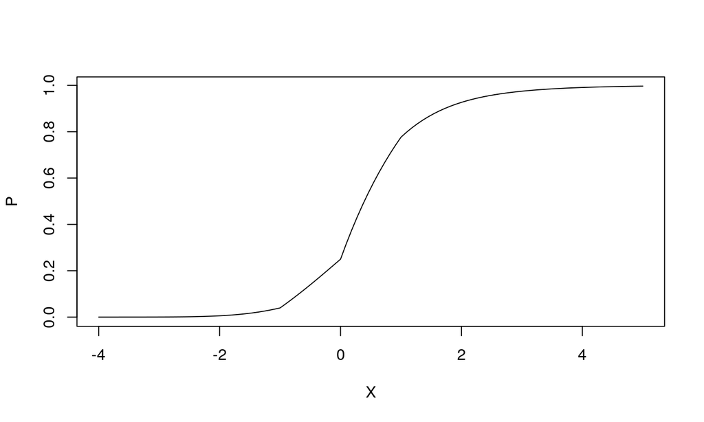

## A quick note on sampling distributions

(Book section 7.2. Will come back to this.)

[figure not shown]

## A quick note on sampling distributions

(Book section 7.2. Will come back to this.)

[figure not shown]